# inlinehelp_view_study_publish_de-deu – IRTlib

### Veröffentlichen

Bevor eine *Version* einer *Studie* zu veröffentlicht wird, kann über die Schaltfläche *Validieren* geprüft werden, ob die *Studie* fehlerfrei konfiguriert wurde.

Eine *Studie* muss beispielsweise immer mindestens einen *Erhebungsteil* enthalten. Ist das nicht der Fall, erscheint beim *Validieren* die folgende Meldung:

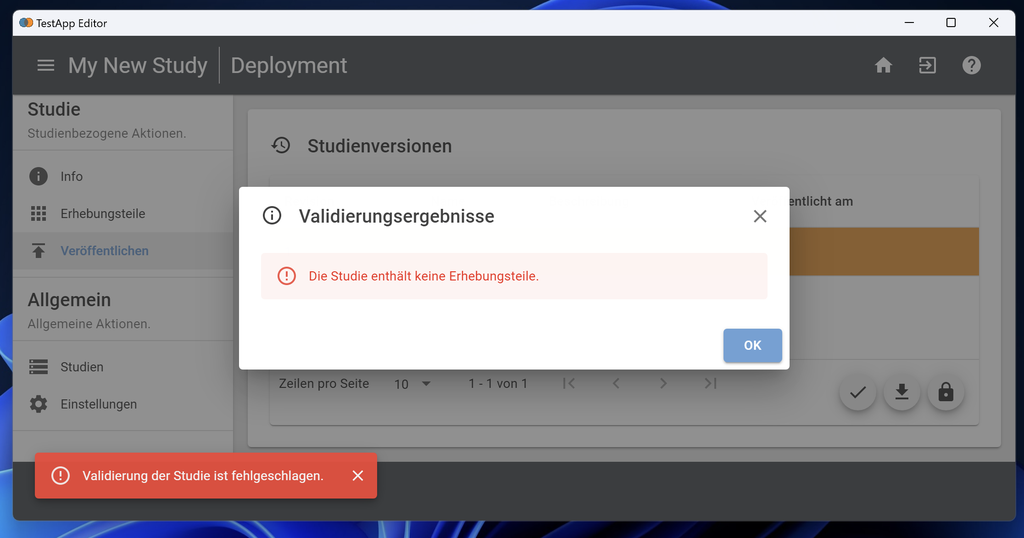

Hinweis: Werden keine Fehler beim *Validieren* gefunden, wird keine weitere Nachricht angezeigt und die Studie kann veröffentlicht werden.

Danach erscheint der folgende Dialog:

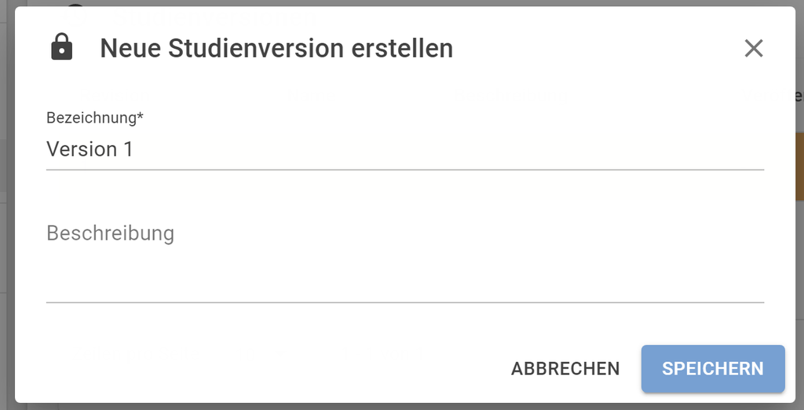

Versionen benötigen eine *Bezeichnung* und können optional mit einer *Beschreibung* dokumentiert werden. Nach dem Bestätigen mit *Speichern* erscheint die *Studie* mit einem *Veröffentlichungsdatum* in der Liste:

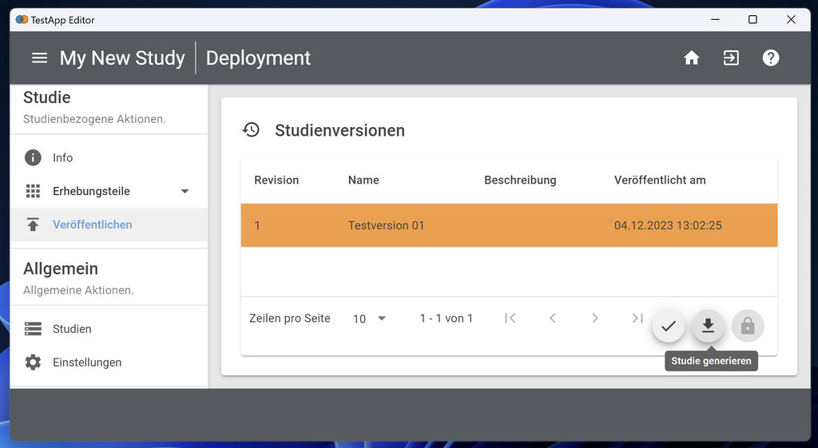

### Exportieren

Nach dem Betätigen dieser Schaltfläche erscheint ein *Save As* / *Speichern unter* - Dialog, und die vollständige Studienkonfiguration kann als ZIP-Archiv gespeichert werden. Dieses ZIP-Archiv kann dann in einem nächsten Schritt verwendet werden, um es in einen *IRTlib Player* zu laden.

### Studienversionen

Die *IRTlib Software* ist so erstellt, dass im Datensatz immer die *Revision* der *Studie* gespeichert wird, sodass nachvollzogen werden kann, mit welcher Konfiguration (d.h. welche *CBA ItemBuilder*-Inhalten und Einstellungen im *IRTlib Editor*) Daten erhoben werden.

**Unveröffentlichte Versionen**: Es ist auch möglich, nicht veröffentlichte Versionen herunterzuladen und in einem *IRTlib Player* auszuprobieren. Zur Sicherheit wird dann aber eine farbliche Markierung während der Testung angezeigt, damit klar ersichtlich ist, dass es sich hierbei nur um eine Vorabversion handelt. Mit nicht veröffentlichten Studien sollten niemals Daten erhoben werden.

**Änderungen veröffentlichter Versionen**: Versionen *versiegeln* die Konfiguration, und machen Änderungen durch eine *Revisionsnummer*, eine *Bezeichnung* und eine optionale *Beschreibung* nachvollziehbar. Änderungen nach dem Versiegeln einer Version sind aber weiterhin möglich. Bevor veränderte Versionen für eine Datenerhebung verwendet werden können, müssen diese aber ebenfalls versiegelt werden, d.h. eine neue *Version* muss über *Veröffentlichen* erstellt werden.